# Ingénierie Financière et Statistique

[Junholv OBO]

# PARIE 1

### Titre : Estimation de la tendance d’un problème de réflexion de Skorokhod associé à

### une équation différentielle dirigée par le mouvement brownien fractionnaire et à un

### processus de rafle de Moreau avec application en finance.

**Descriptif** : Soit **S(t)** le prix d’un actif risqué à la date t, modélisé par l’équation différentielle stochastique :

```python
%%latex
\begin{align}
dS(t)=\mu S(t) dt+ \sigma S(t) dB(t)
\end{align}
```

\begin{align} dS(t)=\mu S(t) dt+ \sigma S(t) dB(t) \end{align}

```python
%%latex
Où \begin{align}\mu \in\Bbb{R}
\end{align}
```

Où \begin{align}\mu \in\Bbb{R} \end{align}

**B** est un mouvement brownien

```python
%%latex
\begin{align}\sigma \end{align}
Un processus au moins contraint à
prendre des valeurs positives.
```

\begin{align}\sigma \end{align} Un processus au moins contraint à prendre des valeurs positives.

Pour cela, une façon de procéder consiste à modéliser : \begin{align}\sigma \end{align}

par le problème de réflexion de Skorokhod

```python
%%latex
\begin{align}
d\sigma(t)=b(\sigma(t) )dt + \varepsilon dB_{H}(t) + Y(t)
\end{align}
```

\begin{align} d\sigma(t)=b(\sigma(t) )dt + \varepsilon dB_{H}(t) + Y(t) \end{align}

Où **Y** est un processus repoussant avec une force minimale \begin{align}\sigma \end{align} à l’intérieur d’un segment:

[m(t), M(t)]

#### Importation des libs

```python
import pandas as pd
import numpy as np
import math

import matplotlib.pyplot as plt
%matplotlib inline
```

# MODEL

$\sigma^{n}_{k+1}= \sigma^n_k + b(\sigma^n_k)(t^{n}_{k+1}-t^{n}_{k}) + \varepsilon(\sigma^n_k)(B^H_{t_{k+1}}- B^H_{t_{k}})$

$\\b(x)=-\theta{x}$

$\\\varepsilon{(x)} = \varepsilon \in \mathbb{R}$

$\\t^{n}_{k+1}-t^{n}_{k} = \frac{T}{N}$

(1) $\sigma^{n}_{k+1}= P^⊥_{c(t_{k+1})}(\sigma^n_k - \theta \cdot\sigma^n_k \cdot\frac{T}{N} + \varepsilon(B^H_{t^{n}_{k+1}}- B^H_{t^{n}_{k}})) = \begin{cases} M({t^{n}_{k+1}}) & \text{si}\ \text{ }\ M({t^{n}_{k+1}}) \leq \tilde{\sigma}^{n}_{k+1} \\ m({t^{n}_{k+1}}) & \text{si}\ \text{ }\ m({t^{n}_{k+1}}) \geq \tilde{\sigma}^{n}_{k+1}\\ \tilde{\sigma}^{n}_{k+1} & \text{si}\ \text{ }\ m({t^{n}_{k+1}}) < \tilde{\sigma}^{n}_{k+1} < M({t^{n}_{k+1}}) \end{cases}$

# Implementation du model

## Mouvement Brownien Fractionnaire

```python
#définition du mb fractionnaire
import numpy as np
import numpy.random as rd
import scipy.linalg as lalg
from scipy.fftpack import fft, ifft


# our covariance function
def cov(h, n):
    if n >= 1:
        return 0.5 * ((n + 1) * (2 * h) + (n - 1) * (2 * h)
                      - 2 * n ** (2 * h))
    else:
        print("index 0 in cov function")
        return False

# vectorize it for further use
vec_cov = np.vectorize(cov)


# circulant coefficients function:
def circ_coefs(h, n):
    m = 2 * (n - 1)
    index = np.arange(1, m)
    coefs = np.zeros(m)
    coefs[0] = 1
    coefs[1:n] = vec_cov(h, index[:n - 1])
    coefs[n:] = vec_cov(h, m - index[n - 1:])
    return coefs


# circulant matrix
def mat_circ(h, n):
    coefs = circ_coefs(h, n)
    return lalg.circulant(coefs)


# fft matrix and diagonal matrix with sqrt of eigenvalues
def eigen_values(h, n):
    m = 2 * (n - 1)
    j = np.ones((m, m))
    j[0, :] = np.zeros(m)
    j = np.cumsum(j, axis=0)
    k = np.zeros((m, m))
    k[:, 1:] = np.ones((m, m - 1))
    k = np.cumsum(k, axis=1)
    q = 1 / np.sqrt(m) * np.exp(-2 * 1j * np.pi * (1 / m) * j * k)
    coefs = circ_coefs(h, n)
    q_t = np.transpose(q)
    eigen_complex = np.sqrt(m) * np.dot(q_t, coefs)
    eigen_sqrt = np.sqrt(eigen_complex)
    return eigen_sqrt


def fbm(h, n, t):
    m = 2 * (n - 1)
    # random gaussian
    seed = 10^2
    rd.seed(seed)
    xsi = rd.normal(size=m)
    # computing fbm
    # multiply by 1/sqrt(m)Q* by taking inverse dft
    step1 = ifft(xsi)
    # multiply by vector of eigenvalues
    step2 = np.multiply(step1, eigen_values(h, n))
    # multiply by sqrt(m)Q by taking dft
    fgn = np.real(fft(step2))[:n]
    res = (t / n) ** h * fgn.cumsum()
    return res
```

### Plot les mouvement brownien fractionnaire en fonction de la valeur de hurst

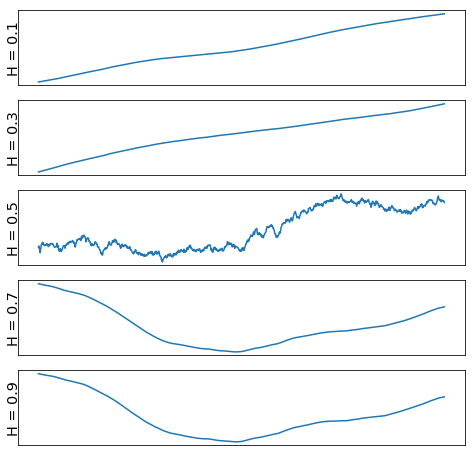

```python
#from fractional_brownian_simulation import *
import matplotlib.pyplot as plt

q = 10
n = 2 ** q + 1
t = 1
h = [0.1, 0.3, 0.5, 0.7, 0.9]
override = {
    'fontsize': 'x-large',
    'verticalalignment': 'center',
    'horizontalalignment': 'center'
}
fig = plt.figure(figsize=(8, 8))

plot1 = fig.add_subplot(511)
plot1.grid(False)
plot1.set_xticks([])
plot1.set_yticks([])
motion = fbm(h[0], n, t)
times = np.arange(len(motion))
plot1.plot(times, motion)
plot1.set_ylabel("H = {}".format(h[0]), override)

plot2 = fig.add_subplot(512)
plot2.grid(False)
plot2.set_xticks([])
plot2.set_yticks([])
motion = fbm(h[1], n, t)
plot2.plot(times, motion)
plot2.set_ylabel("H = {}".format(h[1]), override)

plot3 = fig.add_subplot(513)
plot3.grid(False)
plot3.set_xticks([])
plot3.set_yticks([])
seed = 10^2
rd.seed(seed)
x = rd.normal(size=n)
motion = np.sqrt(t / n) * np.cumsum(x)
plot3.plot(times, motion)
plot3.set_ylabel("H = {}".format(h[2]), override)

plot4 = fig.add_subplot(514)
plot4.grid(False)
plot4.set_xticks([])
plot4.set_yticks([])
motion = fbm(h[3], n, t)
plot4.plot(times, motion)
plot4.set_ylabel("H = {}".format(h[3]), override)

plot5 = fig.add_subplot(515)
plot5.grid(False)
plot5.set_xticks([])
plot5.set_yticks([])
motion = fbm(h[4], n, t)
plot5.plot(times, motion)
plot5.set_ylabel("H = {}".format(h[4]), override)
plt.show()
```

## MOUVEMENT BROWNIEN FRACTIONNAIRE

```python
%%latex
\begin{align}
B_{t}^H
\end{align}
```

\begin{align} B_{t}^H \end{align}

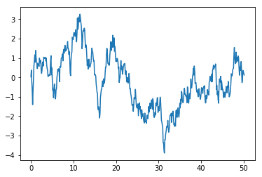

```python
h = .5
N = 500
dt  =  0.1   # Pas de temps.
T  =  50.1   # Temps total.
n  =  int(T/dt)   # Nombre de pas de temps.
t  =  np.linspace (0.,T,n)   # Vecteur de temps.
W_MBF = fbm(h, n, T)
plt.plot(t,W_MBF)
```

# MODEL IMPLEMENTE

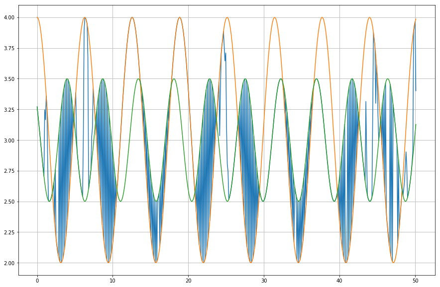

```python
import numpy as np
import matplotlib.pyplot as plt

"""Nous définissons quelques paramètres pour notre modèle:"""

h=0.5
epsy  =  1
teta = 1
def b(x):
     return -teta * x   # Moyenne.
tau  =  .05   # Constante de temps.

"""Définissons quelques paramètres de simulation:"""

N = 500
dt  =  0.1   # Pas de temps.
T  =  50.1   # Temps total.
n  =  int(T/dt)   # Nombre de pas de temps.
t  =  np.linspace (0.,T,n)   # Vecteur de temps.

"""Nous définissons également des variables renormalisées
(pour éviter de recalculer ces constantes à chaque pas de temps):"""
#sigma_bis = sigma * np.sqrt(2. / tau)
sqrtdt = np.sqrt(dt)

"""Nous créons un vecteur qui contiendra toutes les valeurs successives de notre processus
pendant la simulation:"""
W = np.zeros(n)
M = np.zeros(n)
m = np.zeros(n)

"""On crée ici les droites Y1 et Y2 qui seront nos qui vont encadrer sigma"""
# X = np.linspace(0.5, 3.5, 5)
X = np.linspace(0,T,N+1)
Y1 = 3+np.cos(X)
Y2 = 3+np.cos(1+X/0.75)/2
Y3 = np.random.uniform(Y1, Y2, len(X))
SIGMA = np.zeros(n)
diff_W_H_t_i = np.zeros(n)

for i in range(len(X)):
    M[i] = Y1[i]
    m[i] = Y2[i]

for i in range(n - 1):
    #S[i + 1] = S[i] + dt * (-(S[i] - mu) / tau) + sigma_bis * sqrtdt * np.random.randn()
        diff_W_H_t_i = W_MBF[::] - W_MBF[::-1]
        SIGMA[i + 1] = SIGMA[i] - teta * SIGMA[i] * (T/n) + epsy * diff_W_H_t_i[i]
        for i in range(N):
            if SIGMA[i]  > M[i] :
                  SIGMA[i] = M[i]
            elif SIGMA[i] < m[i] :
                SIGMA[i] = m[i]

plt.figure(figsize=(15,10))
plt.plot(t,SIGMA)
plt.plot(t,Y1)
plt.plot(t,Y2)
plt.grid(True)
```

## Mouvement Brownien

```python
%%latex
\begin{align}
B_{t}
\end{align}
```

\begin{align} B_{t} \end{align}

[figure not shown]

```python
############
# N = 500
# dt  =  0.001   # Pas de temps.
# T  =  .501   # Temps total.
# n  =  int(T/dt)   # Nombre de pas de temps.
# t  =  np.linspace (0.,T,n)   # Vecteur de temps.
############

# simuler les incréments par un générateur de variables aléatoires normales
W0 = [0]
increments = np.random.normal(0, 1*np.sqrt(dt), N)
W = W0 + list(np.cumsum(increments))

plt.plot(t, W)
plt.xlabel('time')
plt.ylabel('Mouvement Brownien')
plt.grid(True)
```

## SIMULATION

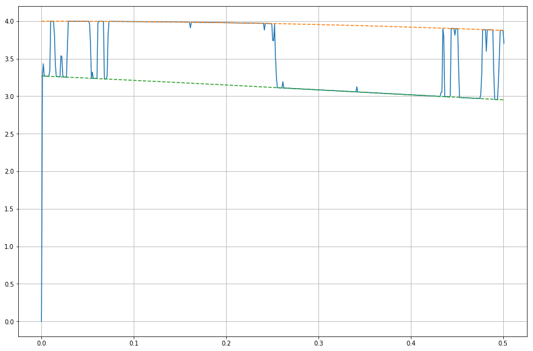

```python
import numpy as np
import matplotlib.pyplot as plt

"""Nous définissons quelques paramètres pour notre modèle:"""

h=0.5
epsy  =  1
teta = 1
def b(x):
     return -teta * x   # Moyenne.
tau  =  .05   # Constante de temps.

"""Définissons quelques paramètres de simulation:"""

N = 500
dt  =  0.001   # Pas de temps.
T  =  .501   # Temps total.
n  =  int(T/dt)   # Nombre de pas de temps.
t  =  np.linspace (0.,T,n)   # Vecteur de temps.

"""Nous définissons également des variables renormalisées
(pour éviter de recalculer ces constantes à chaque pas de temps):"""
#sigma_bis = sigma * np.sqrt(2. / tau)
sqrtdt = np.sqrt(dt)

"""Nous créons un vecteur qui contiendra toutes les valeurs successives de notre processus
pendant la simulation:"""
W = np.zeros(n)
M = np.zeros(n)
m = np.zeros(n)

"""On crée ici les droites Y1 et Y2 qui seront nos qui vont encadrer sigma"""
# X = np.linspace(0.5, 3.5, 5)
X = np.linspace(0,T,N+1)
Y1 = 3+np.cos(X)
Y2 = 3+np.cos(1+X/0.75)/2
Y3 = np.random.uniform(Y1, Y2, len(X))
SIGMA = np.zeros(n)
diff_W_H_t_i = np.zeros(n)

for i in range(len(X)):
    M[i] = Y1[i]
    m[i] = Y2[i]

for i in range(n - 1):
    #S[i + 1] = S[i] + dt * (-(S[i] - mu) / tau) + sigma_bis * sqrtdt * np.random.randn()
        diff_W_H_t_i = W_MBF[::] - W_MBF[::-1]
        SIGMA[i + 1] = SIGMA[i] - teta * SIGMA[i] * (T/n) + epsy * diff_W_H_t_i[i]
        for i in range(N-1):
            if SIGMA[i+1]  >= M[i + 1] :
                  SIGMA[i + 1] = M[i + 1]
            elif SIGMA[i + 1] <= m[i + 1] :
                SIGMA[i + 1] = m[i + 1]
            else:
                pass


plt.figure(figsize=(15,10))
plt.plot(t,SIGMA)
plt.plot(t,Y1,"--")
plt.plot(t,Y2,"--")
plt.grid(True)
```

Junholv OBO

```python
!jupyter nbconvert --to=html Volatilite_Contrainte.ipynb
```